# Coursework Report

*N* removed NAs: 3

*N* removed typo: 1

*N* removed <18: 26

*N* total clean: 121

| Group | *N* | *M*<sub>age</sub> | *M*<sub>rating</sub> |
| --- | --- | --- | --- |
| Control | 58 | 20.55 | 6.14 |
| Experim | 63 | 20.32 | 6.74 |

**Main analysis results**

*t*(119) = -4.65, *p* < .001

[interactive chart not shown]

[figure not shown]

[interactive chart not shown]

# Coursework Report

Analysing Data, Spring 2020

# Methods

## Participants

Table 2 presents the descriptive of the participants’ ages by condition.

Table 1 *Descriptive statistics by Age*

| Mean | SD | Min | Max |
| --- | --- | --- | --- |
| 20.43 | 2.06 | 18 | 28 |

Table 2 *Participant descriptives by experimental condition

| Condition | *N* | Mean | SD | Min | Max |
| --- | --- | --- | --- | --- | --- |
| control | 58 | 20.55 | 2.08 | 18 | 26 |
| experimental | 63 | 20.32 | 2.05 | 18 | 28 |

## Design

The study intended to investigate how women’s perception of a man’s attractiveness is influenced by the colours white and red. Due to prior research, red was selected as the experimental colour and white as the control (the colours were presented through the backgrounds of two photos). Therefore, the predictor variable of this study was the colour of the background and the outcome variable was the perceived attraction of the men by the women. The predictor was categorical with two levels: white and red.

Overall attractiveness was based on three factors that were presented to the participants as questions: “How attractive do you think this person is?” (Item 1), “How pleasant is this person to look at?” (Item 2), “If I were to meet the person in this picture face to face, I would think he is attractive” (Item 3). Each was measured using a Likert rating scale from 1-9, 1 being least attraction and 9 being most, this is a continuous variable. Ultimately, women’s perception of men’s mean attractiveness on a scale from 1 to 9 is influenced by the presence of either white or red. To analyse the significance of the relationship a t-test will be used.

# Results

Table 3 *Descriptive statistics of item ratings*

| Condition | *N* | Item 1 *M* | Item 1 *SD* | Item 2 *M* | Item 2 *SD* | Item 3 *M* | Item 3 *SD* |
| --- | --- | --- | --- | --- | --- | --- | --- |
| control | 58 | 6.19 | 1.13 | 6.12 | 1.33 | 6.10 | 1.25 |
| experimental | 63 | 6.94 | 1.34 | 6.44 | 1.30 | 6.83 | 1.09 |

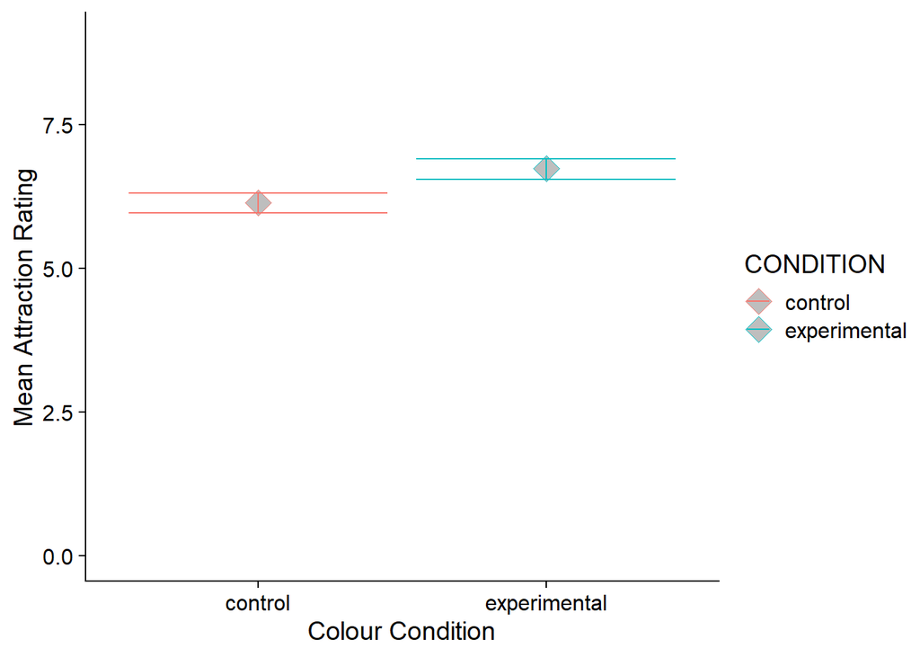

Figure.1 Mean Attraction Rating (1 to 9) by Colour Condition of red and white backgrounds

Participants’ ratings of how attractive, pleasant, and attractive upon meeting the male was, were analysed by the condition of a red or white background. Table 3 shows that while mean ratings between each condition were similar across each item, the experimental condition (red) produced consistently higher ratings than the control (white).

To observe all three items, a composite score was created. The composite score is the mean rating across the items for each participant, making an overall attraction rating. Averaging each composite score, we were able to observe the difference in overall means of attraction between the conditions. Control participants gave an average rating of 6.14, whereas the experimental group gave an average rating of 6.74. As one can see from Figure.1 the mean attraction rating produced by the control condition was lower than the ratings given by the experimental condition. Upon looking just at the graph, the results would support the hypothesis that the colour red may influence the perceived attractiveness of a man from a woman’s perspective. To ensure the significance of our findings, an independent-measures *t*-test was conducted.

The test found that means between the two conditions was rather small (*M*<sub>diff</sub> = -0.6, 95% CI [-0.85, -0.34] however, there was a significant difference between the two groups on ratings of attraction (*t* (119) = -4.65, *p* = .00001).

The *t* value shows that the difference in means was 4 times larger than the standard error of the difference in means. The confidence interval used means there is a 95% chance that any given interval contains the true population mean. As the given confidence intervals do not cross 0, it is extremely unlikely that there is no true difference between the means in the population. Therefore, the null hypothesis is once again extremely unlikely.

# Discussion

This study found that colour influenced women’s attraction towards a man across three factors of attraction, pleasantness, and attraction upon meeting. A picture of a man with a red background was found to be more attractive than a picture of a man with a white background. The study was a replication of a previous study conducted by (Elliot et al., 2010). The original study also found that colour significantly influenced the female participants’ perception of how attractive the man was. This successful replication of results strengthens the theory that the colour red can influence the perceived attractiveness of a male individual and strengthens the experiment’s reliability.

However, a replication of the study conducted by Hesslinger, Goldbach & Carbon (2015) found results that call the reliability of the original study into question. The replication found that there was no effect associating red with higher attraction. Another article criticised the original study and reported beliefs of publication bias, further doubting the sincerity of the study and the true effect of colour on attraction (Francis, 2013).

Furthermore, the effect of colour on attraction may not be as strong as suggested by the successful replication as the study does have some limitations. One limitation of the study is low population validity, the sample ages are limited to 18-28 years. The small range cannot be generalised to the rest of the population and therefore further research must be done to investigate how attraction may be influenced in older age groups. Another limitation is limited ecological validity, due to the study being conducted in a lab. To minimise extraneous variables influencing the participants’ ratings the study was conducted under lab conditions, however, this is an unusual environment in which a participant would normally find or reflect on their attraction to another. Therefore, participants’ results may not reflect true perceptions; this limitation is difficult to resolve without compromising the study’s internal validity. Another limitation that may limit the authenticity of the results could be the use of self report and social desirability bias. Due to difficulties in measuring attraction perceived by another person, researchers are limited to using self-report. The self-report method allows for the possibility of social desirability bias to occur. It is possible that the results given by the participants may be influenced by this bias, perhaps giving a higher rating for attraction across the items to create a less judgemental image of oneself. Lastly, the study only used one male to be in the photos, therefore, the attraction could only be based on this one particular man. To solidify the concept that colour is indeed influenced by colour, it would be beneficial to use many photos of multiple men and/or multiple colour backgrounds. As presented by evaluations by Hesslinger, Goldbach & Carbon (2015), the use of only one male is not reflective of the everyday life in which a female sees many different faces of many different levels of attraction.

Whilst the study does have multiple flaws, there are strengths. The study used three scales to measure the participants’ attraction. Combining three elements of attraction increases the validity of the study and increases the likelihood that the study is measuring attraction, a concept that is difficult to objectively measure. Another strength would be that the participants based attraction off of a picture and not a male in real life. This is a strength because it allows the participants to focus more on the background and they are less distracted by other factors that could influence attraction, such as smell, mannerisms, personality.

Due to the ambivalence revolving the topic and mixed results, further research should take place that investigates areas within the topic that are not covered due to limitations in this experiment. Studies could be conducted using conditions based on the sexuality of the participants, as despite not having a sexual/romantic attraction toward the gender of the photo’s subject, they can recognise attractiveness. This could potentially eliminate subjective attractiveness based on physicality preference but rather potentially produce a more objective, non-bias result. Anther further potential study could investigate the same study at different points of female participants’ menstrual cycles, as similarly investigated by Penton-Voak, et al. (1999). This would help distinguish if the attraction has biological elements or is constructed socially due to the connotations of the colour red (Jacobs, Keown, Worthley and Ghymn, 1991).

Whilst this replication study does hold quite high significance for the effect of colour on attraction, other replications and critiques of the original largely doubt the generalisability and accuracy of the results. This would imply that the theory is not to be followed with high confidence and further replications must take place to ensure either a strong association or to disprove the hypothesis with higher certainty.

# References

Elliot, A. J., Kayser, D. N., Greitemeyer, T., Lichtenfeld, S., Gramzow, R. H., Maier, M. A., & Liu, H. (2010). Red, rank, and romance in women viewing men. *Journal of Experimental Psychology: General, 139*(3), 399–417. doi:10.1037/a0019689

Francis, G. (2013). Publication bias in “Red, rank, and romance in women viewing men,” by Elliot et al. (2010). *Journal of Experimental Psychology: General, 142*(1), 292–296. doi:10.1037/a0027923

Hesslinger, V.M., Goldbach, L. & Carbon, C. Men in red: A reexamination of the red-attractiveness effect. *Psychon Bull Rev 22*, 1142–1148 (2015). https://doi.org/10.3758/s13423-015-0866-8

Jacobs, L., Keown, C., Worthley, R. and Ghymn, K. (1991), “Cross‐cultural Colour Comparisons: Global Marketers Beware!”, *International Marketing Review,* Vol. 8 No. 3. https://doi.org/10.1108/02651339110137279

Penton-Voak, I., Perrett, D., Castles, D. et al. Menstrual cycle alters face preference. *Nature* 399, 741–742 (1999). https://doi.org/10.1038/21557